# FINAL PROJECT (Mehtods of Prediction - Module 507)

```python
from IPython.display import HTML

header = """
<img src="https://www.gisma.com/media/1198/gisma-business-school-logo.svg"
width="240" height="240"style="margin-left:auto ;margin-right:auto "/>'
"""
HTML(header)
```

'

# Business Problem Understanding

As a data scientist, it is important to understand the business problem in order to develop a successful solution. In this case, the business problem is to reduce traffic in the city by implementing a bike sharing system. To do this, our data science team must identify the metrics that will have a significant impact on bike sharing. This includes the day of the week, the time of year, and the weather.

Once these metrics have been identified, our team can then use machine learning and deep learning algorithms to develop a model that can make predictions about future bike sharing usage. This model can then be used to improve service management and optimize the bike sharing system.

In addition, I must also recommand to consider the environmental impact of the bike sharing system. This includes understanding the impact of bike sharing on air pollution and the local environment.

By understanding the business problem and the potential implications of the bike sharing system, I as data science team-lead will try to develop a successful solution that can reduce traffic in the city and improve the local community. By utilizing machine learning and deep learning algorithms, we will develop a model that can make predictions about future bike sharing usage and optimize the bike sharing system.

Dataset address:

https://www.kaggle.com/datasets/hmavrodiev/london-bike-sharing-dataset

# Dataset Feild Description

| **Field Name** | **Description** | **Unit/Format** |
| --- | --- | --- |
| timestamp | Date andTime | Text |
| cnt | Number of shared bikes | Number |
| t1 | Real temperature | Celsius |
| t2 | Feeling temperature | Celsius |
| hum | Humidity | Percentage (%) |
| wind_speed | Wind Speed | KM/H |
| weather_code | Weather Category | Number |
| is_holiday | 1 holiday / 0 non holiday | Boolean |
| is_weekend | 1 if the day is weekend | Boolean |
| season | 0:Spring; 1:Summer; 2:Fall; 3:Winter | Number |

| **weathe_code** | **Description** |
| --- | --- |
| 1 | Clear / Sunny |
| 2 | Scattered clouds / Few clouds |
| 3 | Broken clouds |
| 4 | Cloudy |
| 7 | Rainy |
| 10 | Thunderstorm |
| 26 | Snowfall |

# 1. Importing Libraries

```python
import pandas as pd
import numpy as np
import math

import matplotlib.pyplot as plt
import seaborn as sns

from sklearn import model_selection
from sklearn.preprocessing import RobustScaler
from xgboost.sklearn import XGBRegressor
import xgboost as xgb
from sklearn.metrics import mean_absolute_error
from sklearn.metrics import mean_squared_error
from sklearn.metrics import r2_score
from sklearn.metrics import mean_squared_log_error
from sklearn.metrics import make_scorer
from sklearn.model_selection import GridSearchCV
from tqdm.notebook import tqdm as tqdm
from keras.preprocessing import sequence
from keras.models import Sequential
from keras.layers import Dense
from keras.layers import Dropout
from keras.layers import LSTM
from keras.layers import Bidirectional

%matplotlib inline
```

Pandas as NumPy(pd) are powerful data analysis and manipulation library for Python.

Math library is used to perform basic mathematical operations such as addition, subtraction, multiplication, and division.

Matplotlib and Seaborn are a plotting library for Python. It is used to create 2D graphics, including charts, histograms...

RobustScaler is used to scale numerical data by removing the median and scaling the data according to the quantile range.

XGBRegressor is an XGBoost regressor model from sklearn. It is used to create and evaluate regression models using the XGBoost library.

Mean_absolute_error is a metric from sklearn. It is used to evaluate how close predictions are to their actual values.

Mean_squared_error is a metric from sklearn. It is used to evaluate the difference between predicted and actual values.

Tqdm is a library for displaying progress bars in Python. It is used to visualize the progress of a task, such as a training process or an optimization loop.

Keras (Sequential) is a model from Keras. It is used to create deep learning models, by stacking layers of neural networks together.

Dense is a layer from Keras. It is used to create fully connected layers in a neural network.

Dropout is a layer from Keras. It is used to prevent overfitting in neural networks, by randomly dropping neurons and their connections during training.

LSTM is a layer from Keras. It is used to create a recurrent neural network, which is capable of learning long-term dependencies.

Bidirectional is a layer from Keras. It is used to create a bidirectional recurrent neural network, which can process information in both directions.

# 2. Loading Dataset

```python
df = pd.read_csv("london_merged.csv")
df.head(3)
```

|  | timestamp | cnt | t1 | t2 | hum | wind_speed | weather_code | is_holiday | is_weekend | season |
| --- | --- | --- | --- | --- | --- | --- | --- | --- | --- | --- |
| 0 | 2015-01-04 00:00:00 | 182 | 3.0 | 2.0 | 93.0 | 6.0 | 3.0 | 0.0 | 1.0 | 3.0 |
| 1 | 2015-01-04 01:00:00 | 138 | 3.0 | 2.5 | 93.0 | 5.0 | 1.0 | 0.0 | 1.0 | 3.0 |
| 2 | 2015-01-04 02:00:00 | 134 | 2.5 | 2.5 | 96.5 | 0.0 | 1.0 | 0.0 | 1.0 | 3.0 |

```python
df.dtypes
```

```
timestamp        object
cnt               int64
t1              float64
t2              float64
hum             float64
wind_speed      float64
weather_code    float64
is_holiday      float64
is_weekend      float64
season          float64
dtype: object
```

# 3. Data Exploration

Checking missing values , outliers and rest of the task and changing timestamp field to a proper values

```python
df["timestamp"] = pd.to_datetime(df["timestamp"])
df = df.set_index("timestamp")
df.head()
```

| timestamp | cnt | t1 | t2 | hum | wind_speed | weather_code | is_holiday | is_weekend | season |
| --- | --- | --- | --- | --- | --- | --- | --- | --- | --- |
| 2015-01-04 00:00:00 | 182 | 3.0 | 2.0 | 93.0 | 6.0 | 3.0 | 0.0 | 1.0 | 3.0 |
| 2015-01-04 01:00:00 | 138 | 3.0 | 2.5 | 93.0 | 5.0 | 1.0 | 0.0 | 1.0 | 3.0 |
| 2015-01-04 02:00:00 | 134 | 2.5 | 2.5 | 96.5 | 0.0 | 1.0 | 0.0 | 1.0 | 3.0 |
| 2015-01-04 03:00:00 | 72 | 2.0 | 2.0 | 100.0 | 0.0 | 1.0 | 0.0 | 1.0 | 3.0 |
| 2015-01-04 04:00:00 | 47 | 2.0 | 0.0 | 93.0 | 6.5 | 1.0 | 0.0 | 1.0 | 3.0 |

We'll be creating these features since they could come in handy whilest training some future models.

```python
df["hour"] = df.index.hour
df["day"] = df.index.day
df["week"] = df.index.dayofweek
df["month"] = df.index.month
df["year"] = df.index.year
df.head()
```

| timestamp | cnt | t1 | t2 | hum | wind_speed | weather_code | is_holiday | is_weekend | season | hour | day | week | month | year |
| --- | --- | --- | --- | --- | --- | --- | --- | --- | --- | --- | --- | --- | --- | --- |
| 2015-01-04 00:00:00 | 182 | 3.0 | 2.0 | 93.0 | 6.0 | 3.0 | 0.0 | 1.0 | 3.0 | 0 | 4 | 6 | 1 | 2015 |
| 2015-01-04 01:00:00 | 138 | 3.0 | 2.5 | 93.0 | 5.0 | 1.0 | 0.0 | 1.0 | 3.0 | 1 | 4 | 6 | 1 | 2015 |
| 2015-01-04 02:00:00 | 134 | 2.5 | 2.5 | 96.5 | 0.0 | 1.0 | 0.0 | 1.0 | 3.0 | 2 | 4 | 6 | 1 | 2015 |
| 2015-01-04 03:00:00 | 72 | 2.0 | 2.0 | 100.0 | 0.0 | 1.0 | 0.0 | 1.0 | 3.0 | 3 | 4 | 6 | 1 | 2015 |
| 2015-01-04 04:00:00 | 47 | 2.0 | 0.0 | 93.0 | 6.5 | 1.0 | 0.0 | 1.0 | 3.0 | 4 | 4 | 6 | 1 | 2015 |

```python
col_ord = [
    "season",
    "month",
    "week",
    "day",
    "hour",
    "is_weekend",
    "is_holiday",
    "t1",
    "t2",
    "weather_code",
    "hum",
    "wind_speed",
    "cnt",
]
df = df[col_ord]
df.head()
```

| timestamp | season | month | week | day | hour | is_weekend | is_holiday | t1 | t2 | weather_code | hum | wind_speed | cnt |
| --- | --- | --- | --- | --- | --- | --- | --- | --- | --- | --- | --- | --- | --- |
| 2015-01-04 00:00:00 | 3.0 | 1 | 6 | 4 | 0 | 1.0 | 0.0 | 3.0 | 2.0 | 3.0 | 93.0 | 6.0 | 182 |
| 2015-01-04 01:00:00 | 3.0 | 1 | 6 | 4 | 1 | 1.0 | 0.0 | 3.0 | 2.5 | 1.0 | 93.0 | 5.0 | 138 |
| 2015-01-04 02:00:00 | 3.0 | 1 | 6 | 4 | 2 | 1.0 | 0.0 | 2.5 | 2.5 | 1.0 | 96.5 | 0.0 | 134 |
| 2015-01-04 03:00:00 | 3.0 | 1 | 6 | 4 | 3 | 1.0 | 0.0 | 2.0 | 2.0 | 1.0 | 100.0 | 0.0 | 72 |
| 2015-01-04 04:00:00 | 3.0 | 1 | 6 | 4 | 4 | 1.0 | 0.0 | 2.0 | 0.0 | 1.0 | 93.0 | 6.5 | 47 |

to have a better view we reordered the columns for better explorations

```python
df.dtypes
```

```
season          float64
month             int64
week              int64
day               int64
hour              int64
is_weekend      float64
is_holiday      float64
t1              float64
t2              float64
weather_code    float64
hum             float64
wind_speed      float64
cnt               int64
dtype: object
```

```python
df.describe().transpose()
```

|  | count | mean | std | min | 25% | 50% | 75% | max |
| --- | --- | --- | --- | --- | --- | --- | --- | --- |
| season | 17414.0 | 1.492075 | 1.118911 | 0.0 | 0.0 | 1.0 | 2.00 | 3.0 |
| month | 17414.0 | 6.514643 | 3.452509 | 1.0 | 4.0 | 7.0 | 10.00 | 12.0 |
| week | 17414.0 | 2.992650 | 2.004060 | 0.0 | 1.0 | 3.0 | 5.00 | 6.0 |
| day | 17414.0 | 15.751981 | 8.793704 | 1.0 | 8.0 | 16.0 | 23.00 | 31.0 |
| hour | 17414.0 | 11.513265 | 6.915893 | 0.0 | 6.0 | 12.0 | 18.00 | 23.0 |
| is_weekend | 17414.0 | 0.285403 | 0.451619 | 0.0 | 0.0 | 0.0 | 1.00 | 1.0 |
| is_holiday | 17414.0 | 0.022051 | 0.146854 | 0.0 | 0.0 | 0.0 | 0.00 | 1.0 |
| t1 | 17414.0 | 12.468091 | 5.571818 | -1.5 | 8.0 | 12.5 | 16.00 | 34.0 |
| t2 | 17414.0 | 11.520836 | 6.615145 | -6.0 | 6.0 | 12.5 | 16.00 | 34.0 |
| weather_code | 17414.0 | 2.722752 | 2.341163 | 1.0 | 1.0 | 2.0 | 3.00 | 26.0 |
| hum | 17414.0 | 72.324954 | 14.313186 | 20.5 | 63.0 | 74.5 | 83.00 | 100.0 |
| wind_speed | 17414.0 | 15.913063 | 7.894570 | 0.0 | 10.0 | 15.0 | 20.50 | 56.5 |
| cnt | 17414.0 | 1143.101642 | 1085.108068 | 0.0 | 257.0 | 844.0 | 1671.75 | 7860.0 |

The above table shows the descriptive statistics for a dataset containing 17414 observations. The variables in the dataset include season, month, week, day, hour, is_weekend, is_holiday, t1, t2, weather_code, hum, wind_speed, and cnt. The mean and standard deviations of the variables indicate the spread of the data. The min and max values show the range of the values. The 25%, 50% and 75% values show the quartiles of the data.

```python
print(df.isnull().sum())
print("Duplicate:", df.duplicated().sum())
```

```
season          0
month           0
week            0
day             0
hour            0
is_weekend      0
is_holiday      0
t1              0
t2              0
weather_code    0
hum             0
wind_speed      0
cnt             0
dtype: int64
Duplicate: 0
```

with above code we identify there is no duplicate or missing values

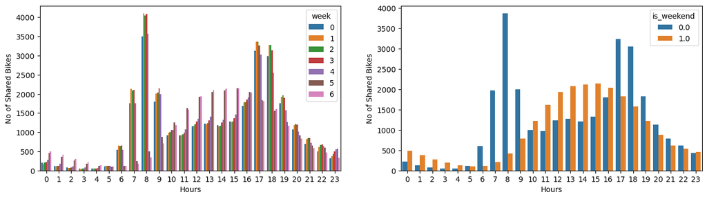

```python
fig, ax = plt.subplots(1, 2, figsize=(16, 4))

day = df.groupby(["hour", "week"])["cnt"].mean().reset_index()
weekend = df.groupby(["hour", "is_weekend"])["cnt"].mean().reset_index()

sns.barplot(ax=ax[0], data=day, x="hour", y="cnt", hue="week")
sns.barplot(ax=ax[1], data=weekend, x="hour", y="cnt", hue="is_weekend")

ax[0].set_xlabel("Hours")
ax[0].set_ylabel("No of Shared Bikes")
ax[1].set_xlabel("Hours")
ax[1].set_ylabel("No of Shared Bikes")

plt.show()
```

Weekends and holidays saw the majority of bike rentals in the afternoon, with weekdays having two peaks that correspond to commute times.

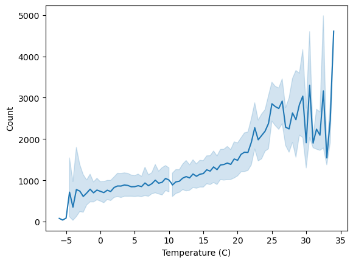

```python
temp = df.groupby(["hour", "t2"])["cnt"].mean().reset_index()
sns.lineplot(data=temp, x="t2", y="cnt")
plt.xlabel("Temperature (C)")
plt.ylabel("Count")
plt.show()
```

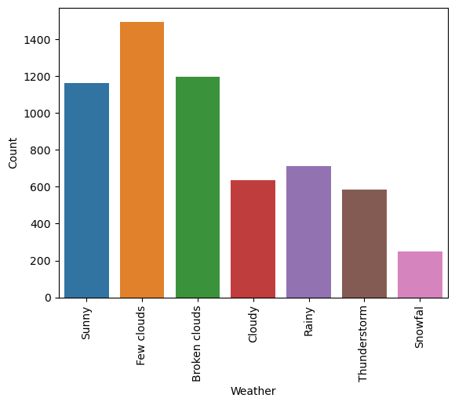

```python
weather_status = df.groupby(["weather_code"])["cnt"].mean().reset_index()
weather_map = {
    1.0: "Sunny",
    2.0: "Few clouds",
    3.0: "Broken clouds",
    4.0: "Cloudy",
    7.0: "Rainy",
    10.0: "Thunderstorm",
    26.0: "Snowfal",
}
weather_status["Weather"] = weather_status["weather_code"].map(weather_map)
sns.barplot(data=weather_status, x="Weather", y="cnt")
plt.xlabel("Weather")
plt.ylabel("Count")
plt.xticks(rotation=90)
plt.show()
```

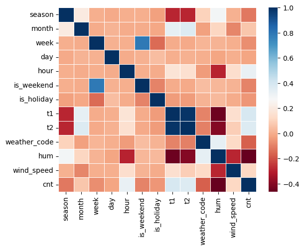

```python
heatmap = df.corr()
sns.heatmap(heatmap, linewidths=0.5, cmap="RdBu")
plt.show()
```

# 4. Outlier detection and Removal

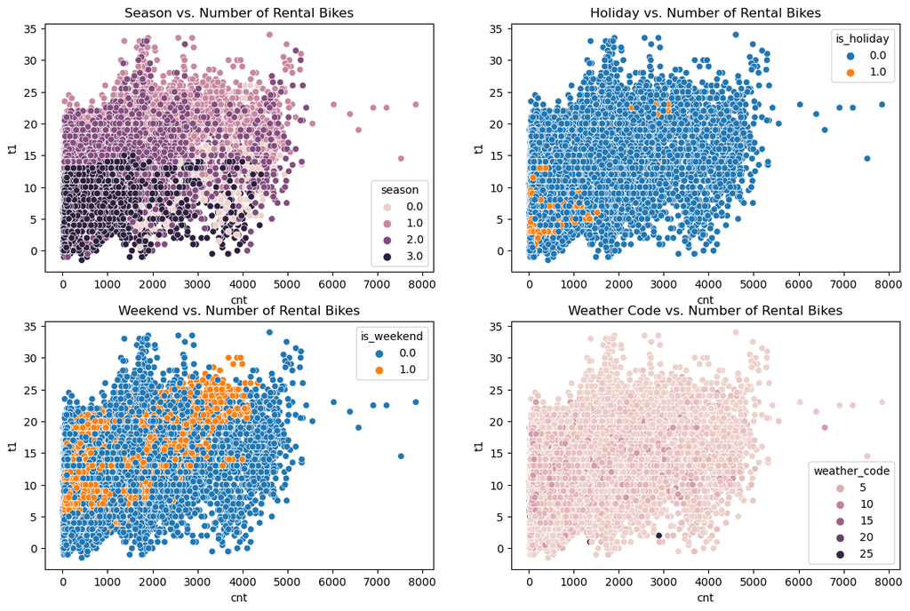

```python
fig = plt.figure(figsize=(14, 9))

ax = fig.add_subplot(221)
sns.scatterplot(x="cnt", y="t1", data=df, hue="season")
ax.set_title("Season vs. Number of Rental Bikes")

ax = fig.add_subplot(222)
sns.scatterplot(x="cnt", y="t1", data=df, hue="is_holiday")
ax.set_title("Holiday vs. Number of Rental Bikes")

ax = fig.add_subplot(223)
sns.scatterplot(x="cnt", y="t1", data=df, hue="is_weekend")
ax.set_title("Weekend vs. Number of Rental Bikes")

ax = fig.add_subplot(224)
sns.scatterplot(x="cnt", y="t1", data=df, hue="weather_code")
ax.set_title("Weather Code vs. Number of Rental Bikes")

plt.show()
```

The above figure shows four scatterplots showing the relationship between bike renting counts (cnt) and temperature (t1). The scatterplots are further separated by the categorical variables season, is_holiday, is_weekend, and weather_code.

```python
df_backup = df.copy()
```

Prior to eliminating outliers, a backup of the original dataset was taken.

```python
q1 = df["cnt"].quantile(0.25)
q3 = df["cnt"].quantile(0.75)
iqr = q3 - q1
df = df[(df["cnt"] >= q1 - 1.5 * iqr) & (df["cnt"] <= q3 + 1.5 * iqr)]
df.shape
```

```
(16739, 13)
```

This code is calculating the interquartile range (IQR) for the "cnt" column in a dataframe, df. The IQR is calculated by first finding the 25th and 75th percentile values (q1 and q3). The IQR is then calculated by subtracting q1 from q3. Any values that fall outside of 1.5 times the IQR are removed from the dataframe, df, before computing its shape.

```python
print("Number of removed outlier records:", df_backup.shape[0] - df.shape[0])
```

```
Number of removed outlier records: 675
```

At the end we eliminated 675 records as outliers from our dataset.

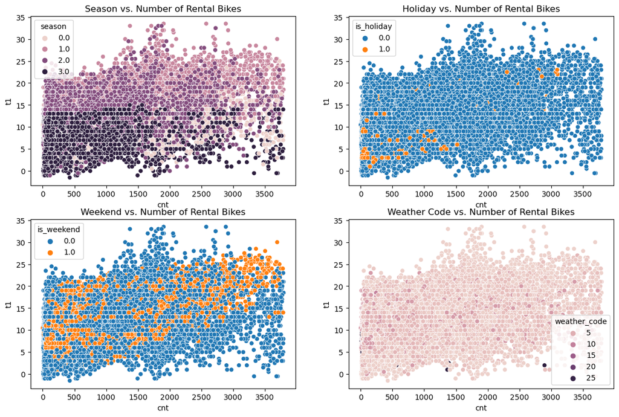

```python
fig = plt.figure(figsize=(14, 9))

ax = fig.add_subplot(221)
sns.scatterplot(x="cnt", y="t1", data=df, hue="season")
ax.set_title("Season vs. Number of Rental Bikes")

ax = fig.add_subplot(222)
sns.scatterplot(x="cnt", y="t1", data=df, hue="is_holiday")
ax.set_title("Holiday vs. Number of Rental Bikes")

ax = fig.add_subplot(223)
sns.scatterplot(x="cnt", y="t1", data=df, hue="is_weekend")
ax.set_title("Weekend vs. Number of Rental Bikes")

ax = fig.add_subplot(224)
sns.scatterplot(x="cnt", y="t1", data=df, hue="weather_code")
ax.set_title("Weather Code vs. Number of Rental Bikes")

plt.show()
```

The aforementioned statistics unmistakably show that outliers were eliminated as compared to earlier plots.

# 5. Furthur Exploration

In the following steps, we'll illustrate more graphs in order to better comprehend the relationships between characteristics and the overall image of bike sharing from various perspectives.

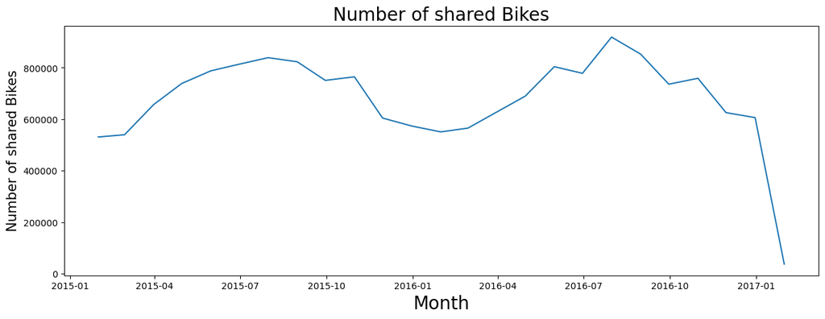

```python
month = df.resample("M").sum()

plt.figure(figsize=(15, 5))
ax = sns.lineplot(data=month, x=month.index, y=month.cnt)
ax.set_title("Number of shared Bikes", fontsize=20)
ax.set_xlabel("Month", fontsize=20)
ax.set_ylabel("Number of shared Bikes", fontsize=15)
plt.show()
```

This figure shows the total number of shared bicycles rented in London in each month from 2015 to 2017. The data shows that the number of shared bicycles rented in London fluctuated significantly throughout the year, with the highest number of bicycles rented during the summer months and the lowest during the winter months. This could be due to the fact that the weather in London is much better during the summer months, which would lead to more people wanting to use the shared bikes.

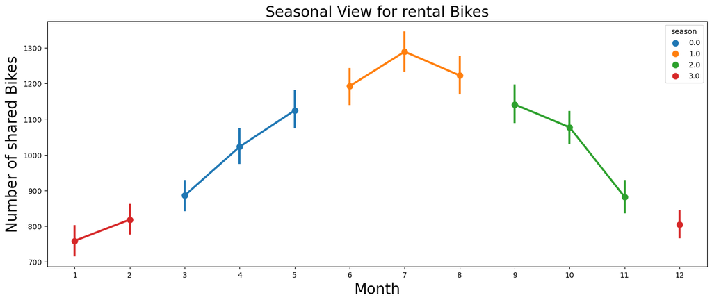

```python
plt.figure(figsize=(16, 6))
ax = sns.pointplot(data=df, hue=df.season, y=df.cnt, x=df.month)
ax.set_title("Seasonal View for rental Bikes", fontsize=20)
ax.set_xlabel("Month", fontsize=20)
ax.set_ylabel("Number of shared Bikes", fontsize=20)
plt.show()
```

This figure shows the number of shared bikes rented in each month during different seasons in London. The graph highlights the seasonal variation in demand for bike rentals. It can be seen that the highest demand is usually in the summer months (June, July and August), whereas the winter months (December, January and February) have the lowest demand for bike rentals. This pattern reflects the seasonal weather conditions in London, with milder and drier weather in the summer months and harsher weather in the winter months.

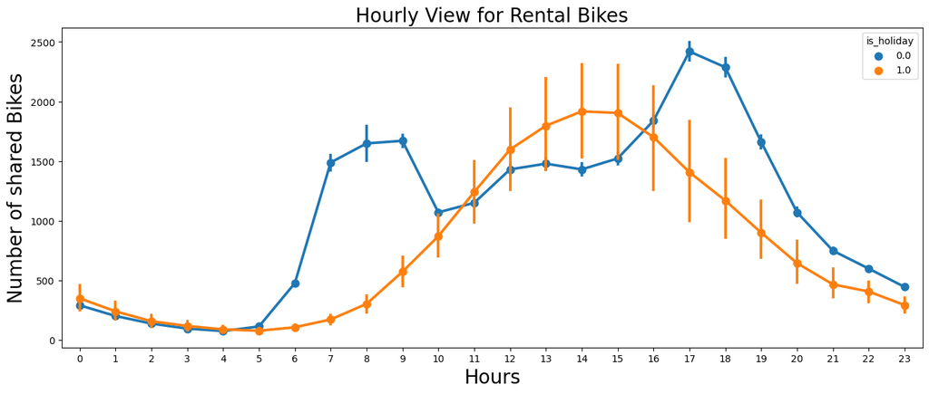

```python
plt.figure(figsize=(16, 6))
ax = sns.pointplot(x="hour", y="cnt", hue="is_holiday", data=df)
ax.set_title("Hourly View for Rental Bikes", fontsize=20)
ax.set_xlabel("Hours", fontsize=20)
ax.set_ylabel("Number of shared Bikes", fontsize=20)
plt.show()
```

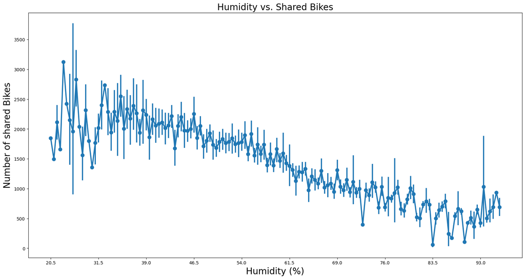

```python
plt.figure(figsize=(20, 10))

ax = sns.pointplot(x="hum", y="cnt", data=df)
ax.set_title("Humidity vs. Shared Bikes", fontsize=20)
ax.set_xlabel("Humidity (%)", fontsize=20)
ax.set_ylabel("Number of shared Bikes", fontsize=20)
plt.locator_params(axis="x", nbins=10)
plt.show()
```

The above figure shows the relationship between the amount of bike shares and the humidity in London. It can be seen that as the humidity increases, the amount of bike shares decreases. This suggests that people are less likely to use a bike share service when the humidity is higher. This could be due to people being more likely to use other forms of transport on days when the humidity is higher.

**Overall we realize that in better weather conditions the number of shared bikes is increasing and also working days are busier than vacations and weekends.**

# 6. Splitting Data

```python
x = df.drop(["cnt"], axis=1)
y = df["cnt"]
```

```python
def df_split(df, train_percent):
    split_index = int(train_percent * len(df))
    train = df.iloc[:split_index]
    test = df.iloc[split_index:]
    return train, test
```

```python
x_train, x_test = df_split(x, 0.7)
y_train, y_test = df_split(y, 0.7)
```

Above block code is used to split our dataset into a training and testing set based on a specified percentage which we have chosen 70%. The code first calculates the split index, which is the index of the last row that should be included in the training set. It then assigns the rows up to the split index to the training set and the remaining rows to the test set. It then returns the two sets.

```python
print("x_train Shape:", x_train.shape)
print("y_train Shape:", y_train.shape)
print("x_test  Shape:", x_test.shape)
print("y_test  Shape:", y_test.shape)
```

```
x_train Shape: (11717, 12)
y_train Shape: (11717,)
x_test  Shape: (5022, 12)
y_test  Shape: (5022,)
```

# 7. Model Selection

**XGBOOST**

```python
parameters_grid = {
    "objective": ["reg:squarederror"],
    "learning_rate": [1, 10],
    "max_depth": [5, 20, 30, 40],
    "min_child_weight": [5, 10],
    "n_estimators": [200, 300, 400],
    "colsample_bytree": [1],
}

model = model_selection.GridSearchCV(
    xgb.XGBRFRegressor(),
    parameters_grid,
    scoring="r2",
    cv=5,
    verbose=2,
    n_jobs=-1,
)
model.fit(x_train, y_train)
print("Accuracy of best XGBoost = {:.2f}".format(model.best_score_))
print("Best found Hyperparameters of XGBoost ={}".format(model.best_params_))
```

```
Fitting 5 folds for each of 48 candidates, totalling 240 fits
Accuracy of best XGBoost = 0.91
Best found Hyperparameters of XGBoost ={'colsample_bytree': 1, 'learning_rate': 1, 'max_depth': 30, 'min_child_weight': 5, 'n_estimators': 300, 'objective': 'reg:squarederror'}
```

```python
prediction = model.predict(x_test)
```

```python
rmse = np.sqrt(mean_squared_error(y_test, prediction))
print("XGBOOST RMSE: %f" % (rmse))
```

```
XGBOOST RMSE: 254.952811
```

This means that the predictions of the model have a large error compared to the actual values.

```python
y_test.values
```

```
array([ 116,  760, 2518, ...,  337,  224,  139], dtype=int64)
```

```python
df.head(3)
```

| timestamp | season | month | week | day | hour | is_weekend | is_holiday | t1 | t2 | weather_code | hum | wind_speed | cnt |
| --- | --- | --- | --- | --- | --- | --- | --- | --- | --- | --- | --- | --- | --- |
| 2015-01-04 00:00:00 | 3.0 | 1 | 6 | 4 | 0 | 1.0 | 0.0 | 3.0 | 2.0 | 3.0 | 93.0 | 6.0 | 182 |
| 2015-01-04 01:00:00 | 3.0 | 1 | 6 | 4 | 1 | 1.0 | 0.0 | 3.0 | 2.5 | 1.0 | 93.0 | 5.0 | 138 |
| 2015-01-04 02:00:00 | 3.0 | 1 | 6 | 4 | 2 | 1.0 | 0.0 | 2.5 | 2.5 | 1.0 | 96.5 | 0.0 | 134 |

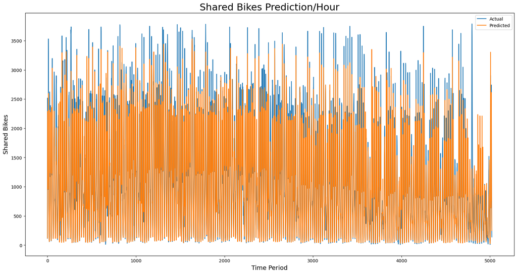

```python
plt.figure(figsize=(20, 10))
plt.plot(y_test.values, label="Actual")
plt.plot(prediction, label="Prediction")

plt.title("Shared Bikes Prediction/Hour", fontsize=22)
plt.xlabel(xlabel="Time Period", fontsize=14)
plt.ylabel(ylabel="Shared Bikes", fontsize=14)
plt.legend(["Actual", "Predicted"])

plt.show()
```

# 8. LSTM (RNN)

We'll be using the Keras library to implement this model.

**Spliting Data**

```python
training_data_len = math.ceil(len(df) * 0.9)
testing_data_len = len(df) - training_data_len

time_steps = 24
train, test = (
    df.iloc[0:training_data_len],
    df.iloc[(training_data_len - time_steps) : len(df)],
)

print(df.shape, train.shape, test.shape)
```

```
(16739, 13) (15066, 13) (1697, 13)
```

The usual splitting dataset through sklearn library is not working here because the dataset is a time series. This means that the data is dependent on the previous values and thus a regular train/test split would result in data leakage. This would lead to overfitting of the model and inaccurate results. Therefore, a different approach is necessary to make sure that the data is properly split and there is no data leakage.

The total length of the dataset is determined by the length of the dataframe (df). We then calculate the training data length as 90% of the total length of the dataset. The remaining 10% of the data is used for testing. The time_steps value is set to 24. Finally, the training and testing datasets are created by taking the respective 90% and 10% of the data from the dataframe.

```python
train_trans = train[
    ["t1", "t2", "hum", "wind_speed", "is_holiday", "is_weekend"]
].to_numpy()
test_trans = test[
    ["t1", "t2", "hum", "wind_speed", "is_holiday", "is_weekend"]
].to_numpy()

scaler = RobustScaler()
train.loc[
    :, ["t1", "t2", "hum", "wind_speed", "is_holiday", "is_weekend"]
] = scaler.fit_transform(train_trans)
test.loc[
    :, ["t1", "t2", "hum", "wind_speed", "is_holiday", "is_weekend"]
] = scaler.fit_transform(test_trans)

train["cnt"] = scaler.fit_transform(train[["cnt"]])
test["cnt"] = scaler.fit_transform(test[["cnt"]])
```

[output not shown]

Firstly, the training and testing datasets are transformed into numpy arrays. Then, a RobustScaler is used which is necessary for handling outliers.

Finally, the training and testing datasets are scaled using the scaler, with the column 'cnt' being scaled separately.

```python
x_train = []
y_train = []

for i in tqdm(range(len(train) - time_steps)):
    x_train.append(train.drop(columns="cnt").iloc[i : i + time_steps].to_numpy())
    y_train.append(train.loc[:, "cnt"].iloc[i + time_steps])

x_train = np.array(x_train)
y_train = np.array(y_train)
```

The given code is used to split the training data into x_train and y_train datasets. A loop is used to iterate through the length of the training data, minus the time steps value. For each iteration, the data from the columns, except 'cnt', is appended to the x_train list. The corresponding 'cnt' value is then appended to the y_train list. Finally, both x_train and y_train are converted to numpy arrays.

```python
x_test = []
y_test = df.loc[:, "cnt"].iloc[training_data_len : len(df)]

for i in tqdm(range(len(test) - time_steps)):
    x_test.append(test.drop(columns="cnt").iloc[i : i + time_steps].to_numpy())

x_test = np.array(x_test)
y_test = np.array(y_test)
```

```python
print("Train size:")
print(x_train.shape, y_train.shape)
print("Test size:")
print(x_test.shape, y_test.shape)
```

```
Train size:
(15042, 24, 12) (15042,)
Test size:
(1673, 24, 12) (1673,)
```

```python
model = Sequential()
model.add(Bidirectional(LSTM(50, input_shape=(x_train.shape[1], x_train.shape[2]))))
model.add(Dropout(0.2))
model.add(Dense(units=1))

model.compile(optimizer="adam", loss="mean_squared_error")
```

The given code is used to create a Bidirectional Long Short-Term Memory (LSTM) model. The first line creates a Sequential model which is used to create a linear stack of layers. The next line adds a Bidirectional LSTM layer to the model, with the input shape being set to the shape of the x_train array. The Dropout layer is then added with a dropout rate of 0.2. Finally, a single Dense layer is added to the model. The model is then compiled with the Adam optimizer and mean squared error loss functions.

Dropout is a regularization technique used to reduce overfitting in neural networks. It randomly sets a fraction of input units to 0 at each update during training time, which helps prevent overfitting by reducing the number of parameters that can be updated.

Dense is a layer type in a neural network that is fully connected to all the neurons in the previous layer.

The 50 in LSTM(50) indicates the number of hidden units in the layer. This number is usually chosen based on the size of the dataset and the complexity of the problem.

```python
history = model.fit(
    x_train, y_train, epochs=50, batch_size=24, validation_split=0.1, shuffle=True
)
```

The given code is used to fit the LSTM model to the training data. The x_train and y_train datasets are passed as parameters to the model.fit() method. The number of epochs, batch size, validation split and shuffle parameters are then set. The model is then trained using the given parameters.

Epochs is the number of times the model will go through the entire dataset during training.

Batch size is the number of samples that will be used in each iteration of training.

Validation split is the percentage of the dataset that will be used for validation.

```python
y_prediction = model.predict(x_test)
y_prediction = scaler.inverse_transform(y_prediction)
y_prediction
```

```
array([[1157.7544 ],
       [1469.3584 ],
       [1712.8352 ],
       ...,
       [ 376.7249 ],
       [ 299.83688],
       [ 141.37622]], dtype=float32)
```

```python
rmse = np.sqrt(mean_squared_error(y_test, y_prediction))
print("LSTM RMSE is:", rmse)
```

```
LSTM RMSE is: 380.88727031674705
```

Above block code is used to calculate the root mean squared error (RMSE) of the predictions made by the LSTM model. The y_test and y_prediction datasets are passed as parameters to the mean_squared_error() method. The RMSE is then calculated and returned.

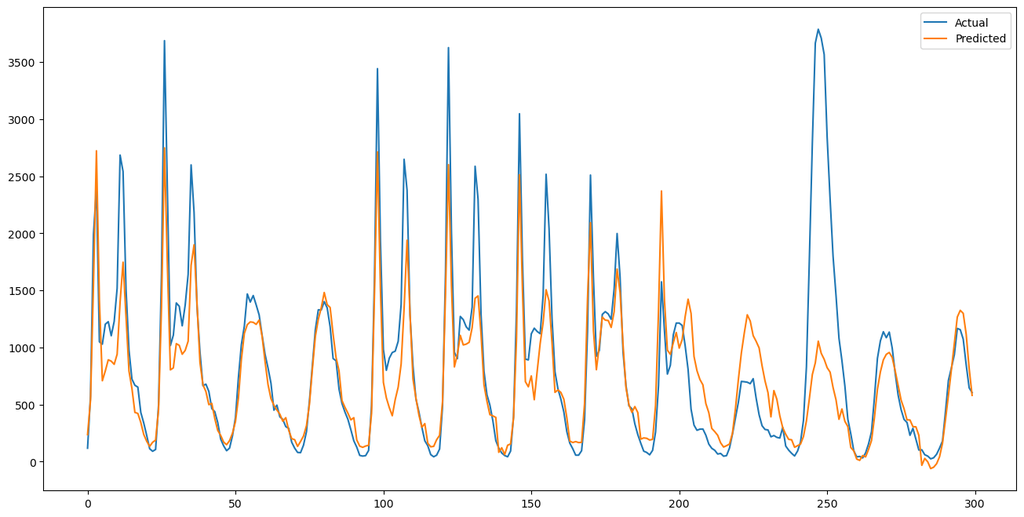

```python
plt.figure(figsize=(16, 8))
plt.plot(y_test[1200:1500], label="Actual")
plt.plot(y_prediction[1200:1500], label="Predicted")
plt.legend()
```

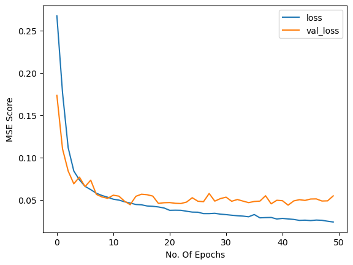

```python
plt.plot(history.history["loss"], label="loss")
plt.plot(history.history["val_loss"], label="val_loss")
plt.legend(loc="best")
plt.xlabel("No. Of Epochs")
plt.ylabel("MSE Score")
```

Above block code is used to plot the loss and validation loss scores of the LSTM model over the number of epochs. The values of the loss and val_loss are obtained from the history object of the model. The x-axis is set to the number of epochs and the y-axis is set to the mse score.

The loss is the measure of the difference between the predicted and actual values on the training dataset. It is used to evaluate the model during training. The val_loss is the measure of the difference between the predicted and actual values on the validation dataset. It is used to evaluate the model after each epoch.

If the loss and val_loss scores of the LSTM model are approximately the same after a certain number of epochs, it indicates that the model has converged and is no longer improving. This means that the model has achieved the best possible performance on the given data.

# 9. Conclusion

The reseon of choosing these two algorithms is that they are two of the most popular and powerful machine learning and deep learning algorithms. XGBoost is a powerful algorithm for regression and classification tasks, and is well-suited for tabular data. LSTM is a powerful deep learning algorithm for sequence prediction tasks, and is well-suited for time series data. Both algorithms are highly accurate and reliable, and have been used successfully in a variety of applications.

# 10. References

1. Brownlee, J. (2020) How to tune LSTM hyperparameters with Keras for time series forecasting, MachineLearningMastery.com. Available at: https://machinelearningmastery.com/tune-lstm-hyperparameters-keras-time-series-forecasting/ (Accessed: December 21, 2022).
2. Mavrodiev, H. (2019) London Bike Sharing Dataset, Kaggle. Available at: https://www.kaggle.com/datasets/hmavrodiev/london-bike-sharing-dataset (Accessed: December 21, 2022).
3. Nayakanti, S. (2020) Long short term memory networks(lstm) in tensorflow, Medium. Analytics Vidhya. Available at: https://medium.com/analytics-vidhya/long-short-term-memory-networks-lstm-in-tensorflow-e986dac5cf27 (Accessed: December 21, 2022).